# EDA_Data Viz

J. Voltz

9/23/2021

## Load the Seoul Bike Sharing

```r
seoul_bike_sharing <- "https://cf-courses-data.s3.us.cloud-object-storage.appdomain.cloud/IBMDeveloperSkillsNetwork-RP0321EN-SkillsNetwork/labs/datasets/seoul_bike_sharing.csv"
seoul_bike_sharing  <- read.csv(seoul_bike_sharing)
```

## Recast DATE as a date

```r
library(dplyr)
seoul_bike_sharing <- seoul_bike_sharing %>%
 mutate(DATE = as.Date(DATE, format = "%m/%d/%y"))

head(seoul_bike_sharing)
```

```
##         DATE RENTED_BIKE_COUNT HOUR TEMPERATURE HUMIDITY WIND_SPEED VISIBILITY
## 1 2020-01-12               254    0        -5.2       37        2.2       2000
## 2 2020-01-12               204    1        -5.5       38        0.8       2000
## 3 2020-01-12               173    2        -6.0       39        1.0       2000
## 4 2020-01-12               107    3        -6.2       40        0.9       2000
## 5 2020-01-12                78    4        -6.0       36        2.3       2000
## 6 2020-01-12               100    5        -6.4       37        1.5       2000
##   DEW_POINT_TEMPERATURE SOLAR_RADIATION RAINFALL SNOWFALL SEASONS    HOLIDAY
## 1                 -17.6               0        0        0  Winter No Holiday
## 2                 -17.6               0        0        0  Winter No Holiday
## 3                 -17.7               0        0        0  Winter No Holiday
## 4                 -17.6               0        0        0  Winter No Holiday
## 5                 -18.6               0        0        0  Winter No Holiday
## 6                 -18.7               0        0        0  Winter No Holiday
##   FUNCTIONING_DAY
## 1             Yes
## 2             Yes
## 3             Yes
## 4             Yes
## 5             Yes
## 6             Yes
```

## Cast HOURS as categorical variable

Coerce its levels to be an ordered sequence

```r
seoul_bike_sharing <- seoul_bike_sharing %>%
 mutate(HOUR =  as.factor(HOUR),
       levels(0:24))

head(seoul_bike_sharing)
```

```
##         DATE RENTED_BIKE_COUNT HOUR TEMPERATURE HUMIDITY WIND_SPEED VISIBILITY
## 1 2020-01-12               254    0        -5.2       37        2.2       2000
## 2 2020-01-12               204    1        -5.5       38        0.8       2000
## 3 2020-01-12               173    2        -6.0       39        1.0       2000
## 4 2020-01-12               107    3        -6.2       40        0.9       2000
## 5 2020-01-12                78    4        -6.0       36        2.3       2000
## 6 2020-01-12               100    5        -6.4       37        1.5       2000
##   DEW_POINT_TEMPERATURE SOLAR_RADIATION RAINFALL SNOWFALL SEASONS    HOLIDAY
## 1                 -17.6               0        0        0  Winter No Holiday
## 2                 -17.6               0        0        0  Winter No Holiday
## 3                 -17.7               0        0        0  Winter No Holiday
## 4                 -17.6               0        0        0  Winter No Holiday
## 5                 -18.6               0        0        0  Winter No Holiday
## 6                 -18.7               0        0        0  Winter No Holiday
##   FUNCTIONING_DAY
## 1             Yes
## 2             Yes
## 3             Yes
## 4             Yes
## 5             Yes
## 6             Yes
```

## Check the df structure

```r
glimpse(seoul_bike_sharing)
```

```
## Rows: 8,465
## Columns: 14
## $ DATE                  <date> 2020-01-12, 2020-01-12, 2020-01-12, 2020-01-12,~
## $ RENTED_BIKE_COUNT     <int> 254, 204, 173, 107, 78, 100, 181, 460, 930, 490,~
## $ HOUR                  <fct> 0, 1, 2, 3, 4, 5, 6, 7, 8, 9, 10, 11, 12, 13, 14~
## $ TEMPERATURE           <dbl> -5.2, -5.5, -6.0, -6.2, -6.0, -6.4, -6.6, -7.4, ~
## $ HUMIDITY              <int> 37, 38, 39, 40, 36, 37, 35, 38, 37, 27, 24, 21, ~
## $ WIND_SPEED            <dbl> 2.2, 0.8, 1.0, 0.9, 2.3, 1.5, 1.3, 0.9, 1.1, 0.5~
## $ VISIBILITY            <int> 2000, 2000, 2000, 2000, 2000, 2000, 2000, 2000, ~
## $ DEW_POINT_TEMPERATURE <dbl> -17.6, -17.6, -17.7, -17.6, -18.6, -18.7, -19.5,~
## $ SOLAR_RADIATION       <dbl> 0.00, 0.00, 0.00, 0.00, 0.00, 0.00, 0.00, 0.00, ~
## $ RAINFALL              <dbl> 0, 0, 0, 0, 0, 0, 0, 0, 0, 0, 0, 0, 0, 0, 0, 0, ~
## $ SNOWFALL              <dbl> 0, 0, 0, 0, 0, 0, 0, 0, 0, 0, 0, 0, 0, 0, 0, 0, ~
## $ SEASONS               <chr> "Winter", "Winter", "Winter", "Winter", "Winter"~
## $ HOLIDAY               <chr> "No Holiday", "No Holiday", "No Holiday", "No Ho~
## $ FUNCTIONING_DAY       <chr> "Yes", "Yes", "Yes", "Yes", "Yes", "Yes", "Yes",~
```

## Check to see if there are missing values

```r
sum(is.na(seoul_bike_sharing))
```

```
## [1] 5208
```

## Dataset summary

```r
summary(seoul_bike_sharing)
```

```
##       DATE            RENTED_BIKE_COUNT      HOUR       TEMPERATURE
##  Min.   :2020-01-01   Min.   :   2.0    7      : 353   Min.   :-17.80
##  1st Qu.:2020-03-12   1st Qu.: 214.0    8      : 353   1st Qu.:  3.00
##  Median :2020-07-01   Median : 542.0    9      : 353   Median : 13.50
##  Mean   :2020-06-21   Mean   : 729.2    10     : 353   Mean   : 12.77
##  3rd Qu.:2020-10-01   3rd Qu.:1084.0    11     : 353   3rd Qu.: 22.70
##  Max.   :2020-12-12   Max.   :3556.0    12     : 353   Max.   : 39.40
##  NA's   :5208                           (Other):6347
##     HUMIDITY       WIND_SPEED      VISIBILITY   DEW_POINT_TEMPERATURE
##  Min.   : 0.00   Min.   :0.000   Min.   :  27   Min.   :-30.600
##  1st Qu.:42.00   1st Qu.:0.900   1st Qu.: 935   1st Qu.: -5.100
##  Median :57.00   Median :1.500   Median :1690   Median :  4.700
##  Mean   :58.15   Mean   :1.726   Mean   :1434   Mean   :  3.945
##  3rd Qu.:74.00   3rd Qu.:2.300   3rd Qu.:2000   3rd Qu.: 15.200
##  Max.   :98.00   Max.   :7.400   Max.   :2000   Max.   : 27.200
##
##  SOLAR_RADIATION     RAINFALL          SNOWFALL         SEASONS
##  Min.   :0.0000   Min.   : 0.0000   Min.   :0.00000   Length:8465
##  1st Qu.:0.0000   1st Qu.: 0.0000   1st Qu.:0.00000   Class :character
##  Median :0.0100   Median : 0.0000   Median :0.00000   Mode  :character
##  Mean   :0.5679   Mean   : 0.1491   Mean   :0.07769
##  3rd Qu.:0.9300   3rd Qu.: 0.0000   3rd Qu.:0.00000
##  Max.   :3.5200   Max.   :35.0000   Max.   :8.80000
##
##    HOLIDAY          FUNCTIONING_DAY
##  Length:8465        Length:8465
##  Class :character   Class :character
##  Mode  :character   Mode  :character
##
##
##
##
```

## Based on the above statistics calculate how many holidays there are

```r
408/24
```

```
## [1] 17
```

## Calculate the percentage of records that fall on a holiday

```r
408/8465
```

```
## [1] 0.04819846
```

## group the data by SEASONS, and use the summarize() function to calculate the seasonal total rainfall and snowfall.

```r
seoul_bike_sharing %>%
    group_by(SEASONS) %>%
    summarize(sum(RAINFALL), sum(SNOWFALL))
```

```
## # A tibble: 4 x 3
##   SEASONS `sum(RAINFALL)` `sum(SNOWFALL)`
##   <chr>             <dbl>           <dbl>
## 1 Autumn            228.             123
## 2 Spring            404.               0
## 3 Summer            560.               0
## 4 Winter             70.9            535.
```

## Load the ggplot2 package so we can generate some data visualizations.

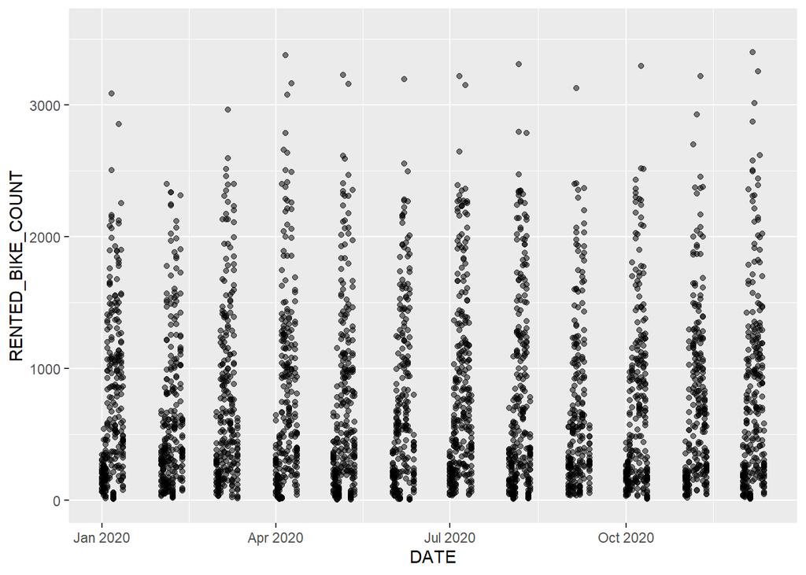

```r
library(ggplot2)
# Create a scatter plot of RENTED_BIKE_COUNT vs DATE
ggplot(seoul_bike_sharing, aes(x = DATE, y = RENTED_BIKE_COUNT)) +
    geom_point(alpha = .5)
```

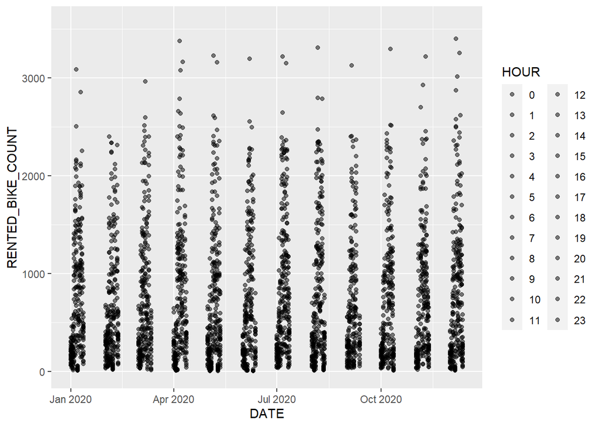

```r
ggplot(seoul_bike_sharing, aes(x = DATE, y = RENTED_BIKE_COUNT, fill = HOUR)) +
    geom_point(alpha = .5)
```

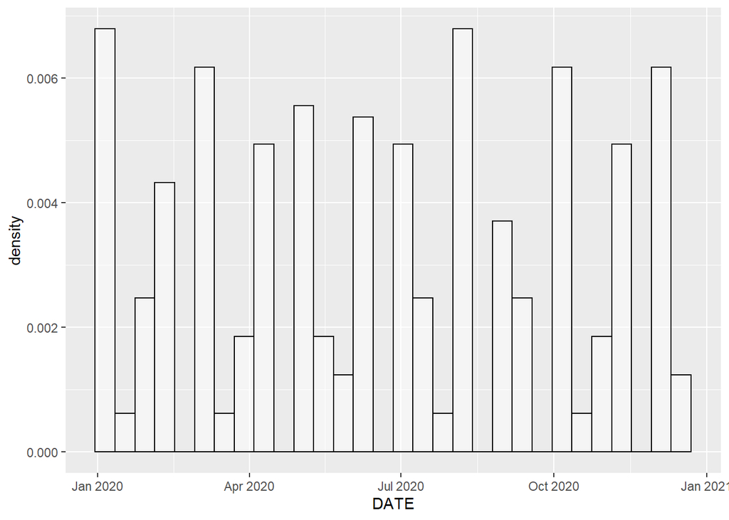

```r
ggplot(seoul_bike_sharing, aes(x = DATE, y = ..density..)) +
    geom_histogram(color = 'black',fill = 'white',alpha = .5)
```

## Correlation between two variables (scatter plot)

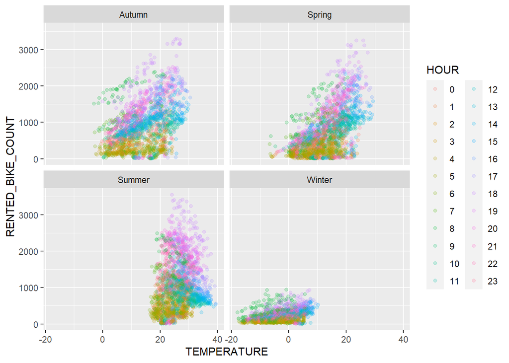

```r
ggplot(seoul_bike_sharing, aes(x = TEMPERATURE, y =RENTED_BIKE_COUNT, color = HOUR)) +
    geom_point(alpha = 1/5) +
    facet_wrap(~SEASONS)
```

Visually, we can see some strong correlations as approximately linear patterns.

Comparing this plot to the same plot below, but without grouping by SEASONS, shows how important seasonality is in explaining bike rental counts.

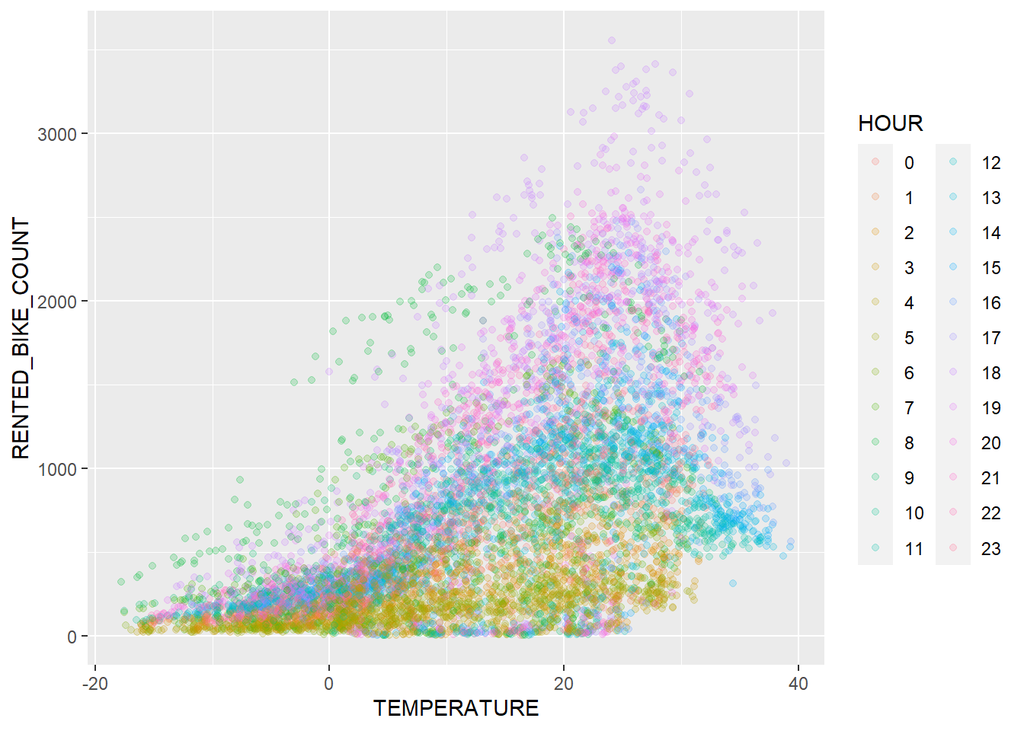

```r
ggplot(seoul_bike_sharing) +
   geom_point(aes(x=TEMPERATURE,y=RENTED_BIKE_COUNT,colour=HOUR),alpha=1/5)
```

## Create a display of four boxplots of RENTED_BIKE_COUNT vs. HOUR grouped by SEASONS.

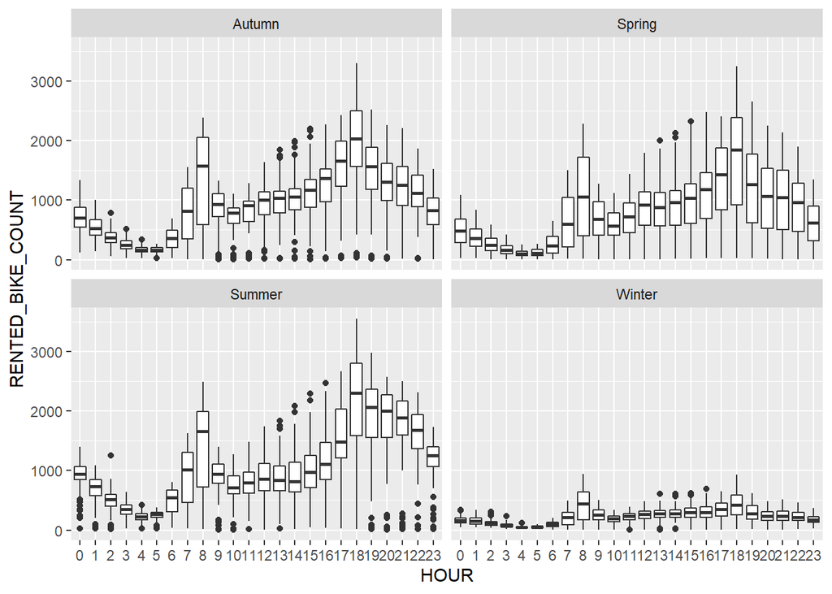

```r
ggplot(seoul_bike_sharing, aes(x=HOUR,y=RENTED_BIKE_COUNT)) +
   geom_boxplot() +
    facet_wrap(~SEASONS)
```

Although the overall scale of bike rental counts changes with the seasons, key features remain very similar. For example, peak demand times are the same across all seasons, at 8 am and 6 pm.

## Group the data by DATE, and use the summarize() function to calculate the daily total rainfall and snowfall.

```r
by_date <- seoul_bike_sharing %>%
    group_by(DATE) %>%
    summarize(Tot_Rain = sum(RAINFALL), Tot_Snow = sum(SNOWFALL))

by_date
```

```
## # A tibble: 137 x 3
##    DATE       Tot_Rain Tot_Snow
##    <date>        <dbl>    <dbl>
##  1 2020-01-01      0        0
##  2 2020-01-02      0       21.7
##  3 2020-01-03      2.5      0
##  4 2020-01-04      0        0
##  5 2020-01-05      0        0
##  6 2020-01-06      0        0
##  7 2020-01-07     81        0
##  8 2020-01-08      0        0
##  9 2020-01-09      0        0
## 10 2020-01-10      0        0
## # ... with 127 more rows
```

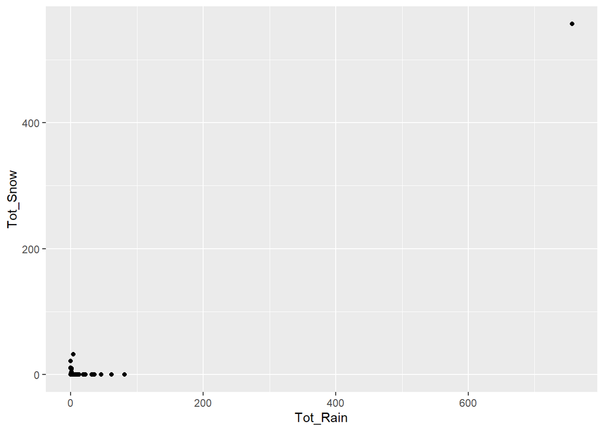

```r
ggplot(by_date, aes(Tot_Rain, Tot_Snow)) +
    geom_point()
```

## Determine how many days had snowfall.

```r
Snow_days <- seoul_bike_sharing %>%
    group_by(DATE)

   count_days <- summarize(Snow_days, count = n(),Tot_Snow = SNOWFALL, na.rm = TRUE)
   count_days <- filter(count_days, Tot_Snow > 0)
   count_days
```

```
## # A tibble: 443 x 4
## # Groups:   DATE [9]
##    DATE       count Tot_Snow na.rm
##    <date>     <int>    <dbl> <lgl>
##  1 2020-01-02    24      1.6 TRUE
##  2 2020-01-02    24      1.6 TRUE
##  3 2020-01-02    24      1.6 TRUE
##  4 2020-01-02    24      1.6 TRUE
##  5 2020-01-02    24      1.6 TRUE
##  6 2020-01-02    24      1.6 TRUE
##  7 2020-01-02    24      1.6 TRUE
##  8 2020-01-02    24      1.6 TRUE
##  9 2020-01-02    24      1.6 TRUE
## 10 2020-01-02    24      1.6 TRUE
## # ... with 433 more rows
```